# Introduction to Linear Regression

### More Practice

1. Choose another freedom variable and a variable you think would strongly correlate with it.. Produce a scatterplot of the two variables and fit a linear model. At a glance, does there seem to be a linear relationship?

Yes, at a glance, there appears to be a slightly positive, weak, linear relationship between pf_religion_restrictions and pf_score.

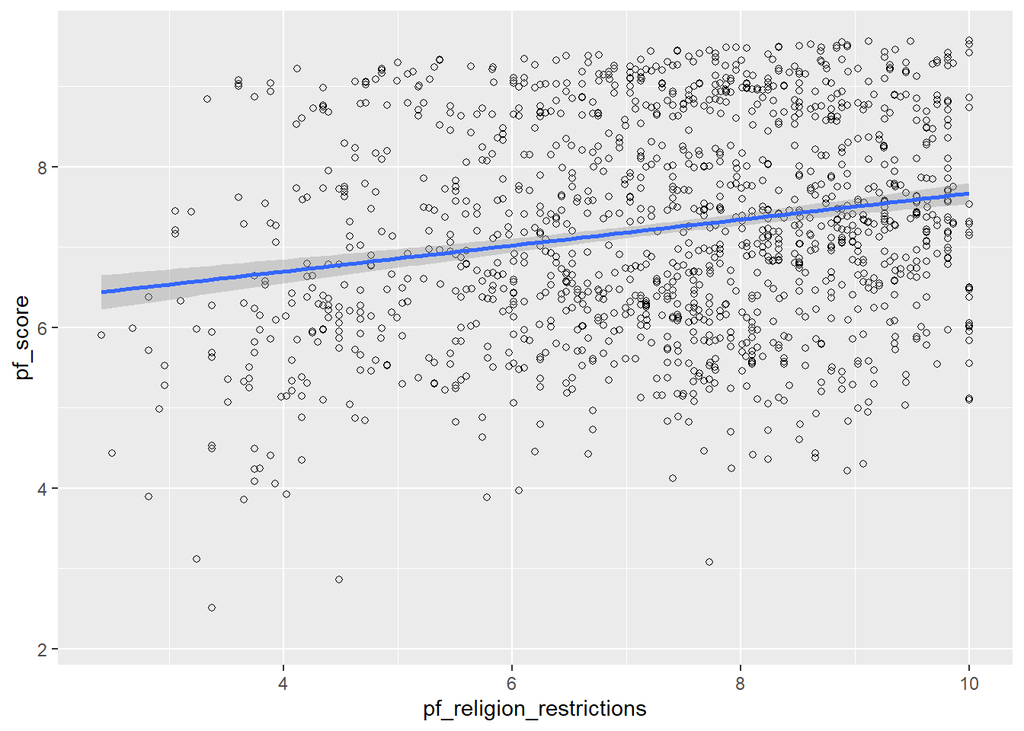

```r
ggplot(hfi, aes(x = pf_religion_restrictions, y = pf_score)) + geom_point(shape=1) + geom_smooth(method = "lm")
```

```r
hfi %>%
  summarise(cor(pf_religion_restrictions, pf_score, use = "complete.obs"))
```

```
## # A tibble: 1 x 1
##   `cor(pf_religion_restrictions, pf_score, use = "complete.obs")`
##                                                             <dbl>
## 1                                                           0.206
```

```r
cor.test(hfi$pf_religion_restrictions, hfi$pf_score)
```

```
##
##  Pearson's product-moment correlation
##
## data:  hfi$pf_religion_restrictions and hfi$pf_score
## t = 7.7725, df = 1362, p-value = 1.507e-14
## alternative hypothesis: true correlation is not equal to 0
## 95 percent confidence interval:
##  0.1547003 0.2563589
## sample estimates:
##       cor
## 0.2060856
```

2. How does this relationship compare to the relationship between pf_expression_control and pf_score? Use the R2 values from the two model summaries to compare. Does your independent variable seem to predict your dependent one better? Why or why not?

This relationship is much weaker than that of pf_expression_control and pf_score with a correlation coefficient of 0.2061. The independent variable does not seem to accurately predict the dependent variable better than pf_expression_control and pf_score. The R2 values from the two model summaries are 0.6342 for pf_expression_control and pf_score and 0.0425 for pf_religion_restrictions and pf_score. The R2 for pf_religion_restrictions and pf_score is much lower than pf_expression_control and pf_score which means the strength of the relationship between pf_expression_control and pf_score is greater and more correlated than pf_religion_restrictions and pf_score. This is why the pf_religion_restriction variable is worse at predicting the dependent pf_score.

```r
# Rsquared of pf religion restrictions and pf score
pfsrr_lm <- lm(pf_religion_restrictions ~ pf_score, data = hfi)
summary(pfsrr_lm)$r.squared
```

```
## [1] 0.04247127
```

```r
# Rsquared of pf expression control and pf score
pfsec_lm <- lm(pf_expression_control ~ pf_score, data = hfi)
summary(pfsec_lm)$r.squared
```

```
## [1] 0.6342361
```

3. What’s one freedom relationship you were most surprised about and why? Display the model diagnostics for the regression model analyzing this relationship.

I would consider the relationship between the rule of law and freedom score the most surprising of the relationships reviewed. The relationship satisfies conditions for the least square regression line but it looks like another type of best fit line may be a better choice. For example, a logistic relationship. The correlation between the variables pf_rol and pf_score are strong, positive, and linear but the residuals display another “u-shaped” trend. The R2 is 0.5997.

```r
# Collect
m4 <- lm(pf_rol ~ pf_score, data = hfi)
summary(m4)
```

```
##
## Call:
## lm(formula = pf_rol ~ pf_score, data = hfi)
##
## Residuals:
##     Min      1Q  Median      3Q     Max
## -3.9396 -0.6811 -0.0765  0.6228  3.4529
##
## Coefficients:
##             Estimate Std. Error t value Pr(>|t|)
## (Intercept) -0.89301    0.13909  -6.421 1.86e-10 ***
## pf_score     0.86133    0.01897  45.401  < 2e-16 ***
## ---
## Signif. codes:  0 '***' 0.001 '**' 0.01 '*' 0.05 '.' 0.1 ' ' 1
##
## Residual standard error: 0.968 on 1376 degrees of freedom
##   (80 observations deleted due to missingness)
## Multiple R-squared:  0.5997, Adjusted R-squared:  0.5994
## F-statistic:  2061 on 1 and 1376 DF,  p-value: < 2.2e-16
```

```r
hfi %>%
  summarise(cor(pf_rol, pf_score, use = "complete.obs"))
```

```
## # A tibble: 1 x 1
##   `cor(pf_rol, pf_score, use = "complete.obs")`
##                                           <dbl>
## 1                                         0.774
```

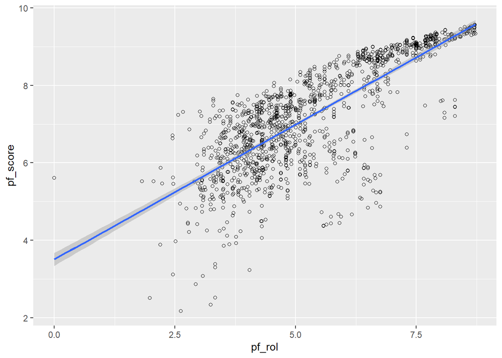

```r
ggplot(hfi, aes(x = pf_rol, y = pf_score)) + geom_point(shape=1) + geom_smooth(method = "lm")
```

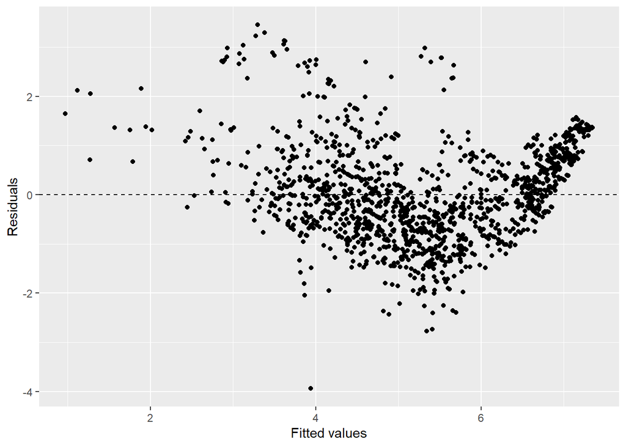

```r
# Visualize
ggplot(data = m4, aes(x = .fitted, y = .resid)) +
  geom_point() +
  geom_hline(yintercept = 0, linetype = "dashed") +
  xlab("Fitted values") +
  ylab("Residuals")
```

```r
pfsrl_lm <- lm(pf_rol ~ pf_score, data = hfi)
summary(pfsrl_lm)$r.squared
```

```
## [1] 0.5996762
```

…